# Question

Random variable $X$ is normally distributed with mean $\mu = 14$ and standard deviation $\sigma = 2$.
$$X \sim \text{N}(14,\,2)$$
Evaluate $P\left(\big|X-14\big| < 1\right)$. In other words, what is the probability that $X$ is within $\pm1$ units from the mean?

# Use online app

[video (using app)](https://vimeo.com/531933725)

# Use z table

[video (using z-table)](https://vimeo.com/531933369)

First, draw a sketch. We can label the $X$ axis by adding integer multiples of 2 to 14. We know to shade the center because values near 14 satisfy the condition $\big|X-14\big| < 1$. We draw the boundaries at $14-1=13$ and $14+1=15$ because those are the solutions to $\big|X-14\big| = 1$. We can also rephrase the probability.

$$P\left(\big|X-14\big| < 1\right) ~=~
P(13<X<15)$$

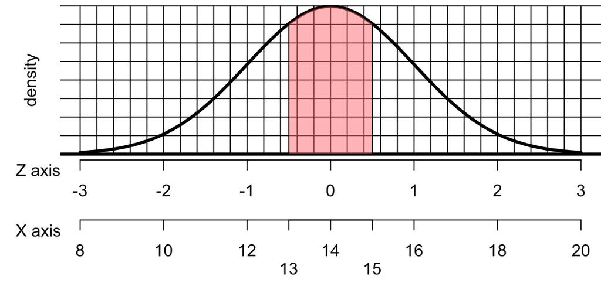

We calculate the $z$ values of the boundaries. Left boundary:
$$\begin{aligned}
z_1 &= \frac{13-14}{2} \\\\
&= \frac{-1}{2} \\\\
&= -0.5
\end{aligned}$$

Right boundary:

$$\begin{aligned}
z_2 &= \frac{15-14}{2} \\\\
&= \frac{1}{2} \\\\
&= 0.5
\end{aligned}$$

We have rephrased our problem into a **standard normal** probability problem, because

$$P\left(\big|X-14\big| < 1\right) ~=~
P(13<X<15) ~=~ P(-0.5<Z<0.5) ~=~
P\left(\big|Z\big|<0.5\right)$$

So, we just need to evaluate $P(|Z|<0.5)$. I will also point out that $\frac{1}{2} = 0.5$. In general, if $X$ is normally distributed, then:
$$P\left(\big|X-\mu\big|<d\right) ~=~
P\left(\big|Z\big| < \frac{d}{\sigma}\right)$$

From here we have a formula that lets us use the $z$ table. (We practiced this part before.)
$$\begin{aligned}
P(|Z|<0.5) &= 2 \times P(Z<0.5)-1 \\
&= 2 \times 0.6915-1 \\
&= 0.383
\end{aligned}$$

# Meta-information

extype: num exsolution: 0.383 exname: Get centralarea from normal extol: 0.0002